# Isopair: Characterizing structural differences between isoform pairs

Pete Castaldi

4 March 2026

# 1 Introduction

How do two isoforms of the same gene differ structurally? **Isopair** answers this question by detecting, characterizing, and comparing structural differences between isoform pairs. The package identifies 12 types of splicing events (alternative TSS/TES, alternative 5’/3’ splice sites, skipped exons, intron retention, and partial intron retention variants), reconstructs reference isoforms from detected events, and builds splicing choice profiles for downstream analysis.

Use cases include NMD target characterization, alternative splicing surveys, and cross-condition comparisons of isoform structure. The workflow proceeds from event detection through profiling to single-set characterization and cross-set comparison.

# 2 Setup

```r
library(Isopair)
```

Isopair ships with example data from 5 genes (SRSF3, SRSF1, BCL2L1, TP63, FAM13A) extracted from GENCODE v49. Three pre-computed objects are available:

```r
data(example_structures)  # parsed isoform structures
data(example_pairs)       # expression-derived pairs
data(example_profiles)    # splicing choice profiles
```

The `example_structures` tibble contains 25 isoforms. The `example_profiles` tibble contains 5 pair profiles with 22 total events.

# 3 Core Workflow

This section walks through the full pipeline from a GTF file to verified profiles.

## 3.1 Parse isoform structures

```r
gtf_path <- system.file("extdata", "example_small.gtf", package = "Isopair")
structures <- parseIsoformStructures(gtf_path, verbose = FALSE)
head(structures[, c("isoform_id", "gene_id", "n_exons")])
```

```
#> # A tibble: 6 × 3
#>   isoform_id         gene_id            n_exons
#>   <chr>              <chr>                <int>
#> 1 ENST00000258962.5  ENSG00000136450.13       4
#> 2 ENST00000264344.10 ENSG00000138640.16      24
#> 3 ENST00000264731.8  ENSG00000073282.14      14
#> 4 ENST00000320472.9  ENSG00000073282.14      12
#> 5 ENST00000339436.11 ENSG00000112081.19       4
#> 6 ENST00000418709.6  ENSG00000073282.14      11
```

## 3.2 Build union exons

Union exons are atomic, non-overlapping segments that serve as a common coordinate system across all isoforms of a gene. Build them from **all isoforms** you plan to analyze:

```r
ue <- buildUnionExons(structures, verbose = FALSE)
head(ue$union_exons)
```

```
#> # A tibble: 6 × 8
#>   gene_id      union_exon_id union_exon_number chr    start    end strand length
#>   <chr>        <chr>                     <int> <chr>  <int>  <int> <chr>   <int>
#> 1 ENSG0000007… ENSG00000073…                 1 chr3  1.90e8 1.90e8 +          27
#> 2 ENSG0000007… ENSG00000073…                 2 chr3  1.90e8 1.90e8 +          72
#> 3 ENSG0000007… ENSG00000073…                 3 chr3  1.90e8 1.90e8 +          90
#> 4 ENSG0000007… ENSG00000073…                 4 chr3  1.90e8 1.90e8 +         129
#> 5 ENSG0000007… ENSG00000073…                 5 chr3  1.90e8 1.90e8 +         133
#> 6 ENSG0000007… ENSG00000073…                 6 chr3  1.90e8 1.90e8 +         122
```

## 3.3 Generate pairs

Load expression data and create isoform pairs. The expression CSV must be converted to a numeric matrix with isoform IDs as rownames:

```r
expr_file <- system.file("extdata", "example_expression.csv",
  package = "Isopair")
expr_df <- read.csv(expr_file)
expr_mat <- as.matrix(expr_df[, -1])
rownames(expr_mat) <- expr_df$isoform_id

gene_map <- unique(as.data.frame(structures[, c("isoform_id", "gene_id")]))
pairs <- generatePairsExpression(expr_mat, gene_map,
  colnames(expr_mat), method = "top_two")
pairs
```

```
#> # A tibble: 5 × 7
#>   gene_id      reference_isoform_id comparator_isoform_id source direction logFC
#>   <chr>        <chr>                <chr>                 <chr>  <chr>     <dbl>
#> 1 ENSG0000007… ENST00000264731.8    ENST00000320472.9     expre… <NA>         NA
#> 2 ENSG0000011… ENST00000930976.1    ENST00000613941.4     expre… <NA>         NA
#> 3 ENSG0000017… ENST00000870621.1    ENST00000450273.2     expre… <NA>         NA
#> 4 ENSG0000013… ENST00000264344.10   ENST00000515155.1     expre… <NA>         NA
#> 5 ENSG0000013… ENST00000258962.5    ENST00000585096.1     expre… <NA>         NA
#> # ℹ 1 more variable: adj_p_val <dbl>
```

## 3.4 Build profiles

Profiles detect events for each pair, reconstruct the reference, and verify the reconstruction:

```r
profiles <- buildProfiles(pairs, structures,
  ue$union_exons, ue$isoform_union_mapping, verbose = FALSE)
```

## 3.5 Verify reconstruction

Every profile includes a reconstruction status. Check that all pairs pass:

```r
table(profiles$reconstruction_status)
```

```
#>
#> PASS
#>    5
```

## 3.6 Summarize

```r
summarizeProfiles(profiles)
```

```
#> $n_profiles
#> [1] 5
#>
#> $n_genes
#> [1] 5
#>
#> $total_events
#> [1] 22
#>
#> $mean_events_per_profile
#> [1] 4.4
#>
#> $event_counts
#>          Alt_TSS          Alt_TES             A5SS             A3SS
#>                5                5                1                1
#>               SE Missing_Internal               IR          IR_diff
#>                3                2                0                0
#>       Partial_IR
#>                5
#>
#> $pct_tss_changed
#> [1] 100
#>
#> $pct_tes_changed
#> [1] 100
#>
#> $mean_junction_similarity
#> [1] 0.2178571
```

# 4 Understanding Events

Isopair detects 12 event types organized in 4 categories:

| Category | Event Types |
| --- | --- |
| Terminal | Alt_TSS, Alt_TES |
| Boundary | A5SS, A3SS, Partial_IR_5, Partial_IR_3 |
| Exon-level | SE, Missing_Internal |
| Intron retention | IR, IR_diff_5, IR_diff_3, IR_diff_5_3 |

**Direction semantics:** Events are described from the comparator’s perspective. **LOSS** means the comparator lost sequence relative to the reference (the reference has more). **GAIN** means the comparator gained sequence (the reference has less).

## 4.1 Examining detailed events

Each profile row contains a nested `detailed_events` tibble. Access it with base R:

```r
profiles$detailed_events[[1]]
```

```
#> # A tibble: 4 × 15
#>   gene_id  reference_isoform_id comparator_isoform_id event_type direction chr
#>   <chr>    <chr>                <chr>                 <chr>      <chr>     <chr>
#> 1 ENSG000… ENST00000264731.8    ENST00000320472.9     Missing_I… LOSS      chr3
#> 2 ENSG000… ENST00000264731.8    ENST00000320472.9     Missing_I… LOSS      chr3
#> 3 ENSG000… ENST00000264731.8    ENST00000320472.9     Alt_TSS    LOSS      chr3
#> 4 ENSG000… ENST00000264731.8    ENST00000320472.9     Alt_TES    LOSS      chr3
#> # ℹ 9 more variables: five_prime <int>, three_prime <int>, strand <chr>,
#> #   bp_diff <int>, missing_terminal_exons <chr>, orphan_terminal_exons <chr>,
#> #   ir_split_exons <chr>, ref_junctions <chr>, comp_junctions <chr>
```

## 4.2 Visualization

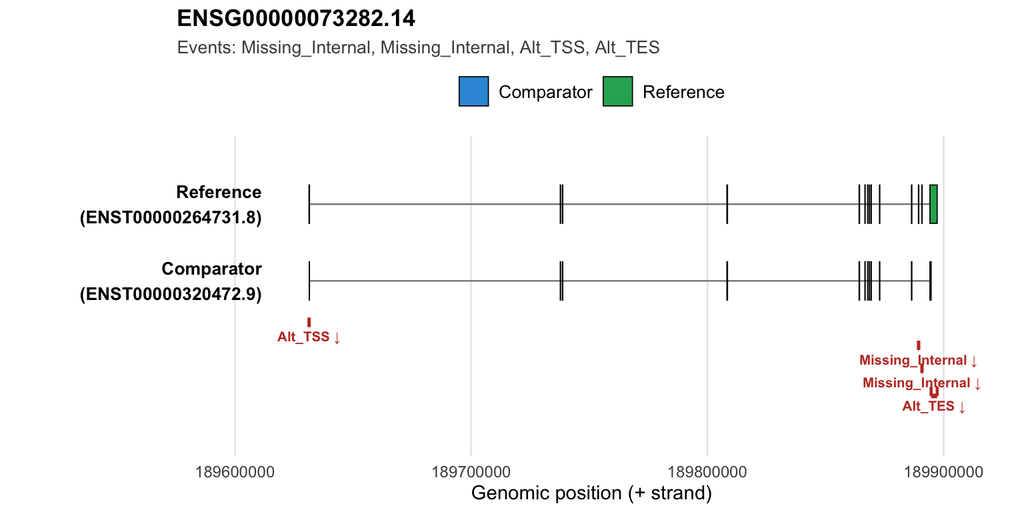

```r
# Get exon data for the first pair
ref_id <- profiles$reference_isoform_id[1]
comp_id <- profiles$comparator_isoform_id[1]
ref_struct <- structures[structures$isoform_id == ref_id, ]
comp_struct <- structures[structures$isoform_id == comp_id, ]

ref_exons <- data.frame(
  exon_start = ref_struct$exon_starts[[1]],
  exon_end = ref_struct$exon_ends[[1]]
)
comp_exons <- data.frame(
  exon_start = comp_struct$exon_starts[[1]],
  exon_end = comp_struct$exon_ends[[1]]
)

events <- profiles$detailed_events[[1]]
plotIsoformPair(ref_exons, comp_exons, events,
  profiles$gene_id[1], ref_id, comp_id,
  ref_struct$strand)
```

# 5 Generating Pairs

Isopair provides three methods for creating isoform pairs, each suited to different experimental designs.

## 5.1 Expression baseline

Pair the two most highly expressed isoforms per gene:

```r
pairs_expr <- generatePairsExpression(expr_mat, gene_map,
  colnames(expr_mat), method = "top_two")
nrow(pairs_expr)
```

```
#> [1] 5
```

## 5.2 Differential expression

First identify dominant isoforms, then pair each significant DE isoform against its gene’s dominant:

```r
de_file <- system.file("extdata", "example_de.csv", package = "Isopair")
de <- read.csv(de_file)
dom <- identifyDominantIsoforms(expr_mat, gene_map, colnames(expr_mat))
pairs_de <- generatePairsDE(de, "isoform_id", "gene_id", "logFC",
  "adj_p_val", dom)
nrow(pairs_de)
```

```
#> [1] 3
```

## 5.3 Differential usage

Pair isoforms based on differential usage results:

```r
du_file <- system.file("extdata", "example_du.csv", package = "Isopair")
du <- read.csv(du_file)
pairs_du <- generatePairsDU(du, "isoform_id", "gene_id", "dPSI",
  "adj_p_val", method = "extreme")
nrow(pairs_du)
```

```
#> [1] 2
```

# 6 Characterizing a Pair Set

This section demonstrates single-set characterization using the pre-computed `example_profiles`.

## 6.1 Event quantification

```r
summarizeProfiles(example_profiles)
```

```
#> $n_profiles
#> [1] 5
#>
#> $n_genes
#> [1] 5
#>
#> $total_events
#> [1] 22
#>
#> $mean_events_per_profile
#> [1] 4.4
#>
#> $event_counts
#>          Alt_TSS          Alt_TES             A5SS             A3SS
#>                5                5                1                1
#>               SE Missing_Internal               IR          IR_diff
#>                3                2                0                0
#>       Partial_IR
#>                5
#>
#> $pct_tss_changed
#> [1] 100
#>
#> $pct_tes_changed
#> [1] 100
#>
#> $mean_junction_similarity
#> [1] 0.2178571
```

## 6.2 Co-occurrence

Test whether event types co-occur more or less often than expected:

```r
cooc <- testCooccurrence(example_profiles)
cooc[, c("event_a", "event_b", "odds_ratio", "p_value")]
```

```
#> # A tibble: 28 × 4
#>    event_a event_b          odds_ratio p_value
#>    <chr>   <chr>                 <dbl>   <dbl>
#>  1 Alt_TSS Alt_TES                   0       1
#>  2 Alt_TSS A5SS                      0       1
#>  3 Alt_TSS A3SS                      0       1
#>  4 Alt_TSS SE                        0       1
#>  5 Alt_TSS Missing_Internal          0       1
#>  6 Alt_TSS IR                        0       1
#>  7 Alt_TSS Partial_IR                0       1
#>  8 Alt_TES A5SS                      0       1
#>  9 Alt_TES A3SS                      0       1
#> 10 Alt_TES SE                        0       1
#> # ℹ 18 more rows
```

With only 5 profiles, most tests lack power. In real analyses with hundreds of pairs, significant co-occurrence patterns emerge.

## 6.3 Spatial analysis

Test whether events are uniformly distributed along the gene span. We lower `min_events` for illustration; use the default (30) for real analyses:

```r
bias <- testPositionalBias(example_profiles, example_structures,
  min_events = 1L)
bias[, c("event_type", "n_events", "median_position", "bias_direction")]
```

```
#> # A tibble: 8 × 4
#>   event_type       n_events median_position bias_direction
#>   <chr>               <int>           <dbl> <chr>
#> 1 Missing_Internal        2          0.973  3' biased
#> 2 Alt_TSS                 5          0.550  None
#> 3 Alt_TES                 5          0.308  None
#> 4 SE                      3          0.439  None
#> 5 Partial_IR_5            2          0.928  None
#> 6 Partial_IR_3            3          0.696  None
#> 7 A3SS                    1          0.0745 None
#> 8 A5SS                    1          0.0739 None
```

### 6.3.1 Topology classification

Classify A5SS/A3SS event pairs into Face-to-Face, Back-to-Back, or Distal topologies:

```r
topo <- classifyTopology(example_profiles, example_structures, test = FALSE)
topo$summary
```

```
#> # A tibble: 1 × 3
#>   topology count proportion
#>   <chr>    <int>      <dbl>
#> 1 B2B          1          1
```

### 6.3.2 Event proximity

Test whether internal events cluster closer than expected by chance:

```r
prox <- testProximity(example_profiles, example_structures, n_perm = 50L)
prox[c("z_score", "p_value", "n_profiles_used")]
```

```
#> $z_score
#> [1] -2.352539
#>
#> $p_value
#> [1] 0
#>
#> $n_profiles_used
#> [1] 4
```

## 6.4 Regional impact

Map events to genomic regions (5’UTR, CDS, 3’UTR) and test for enrichment:

```r
cds <- extractCdsAnnotations(gtf_path, structures$isoform_id, verbose = FALSE)
annotated <- annotateRegionTypes(ue$isoform_union_mapping, cds)
er <- mapEventsToRegions(example_profiles, annotated, cds)
head(er[, c("event_type", "region_type")])
```

```
#> # A tibble: 6 × 2
#>   event_type       region_type
#>   <chr>            <chr>
#> 1 Missing_Internal CDS
#> 2 Missing_Internal CDS
#> 3 Alt_TSS          contains_orf_start
#> 4 Alt_TES          contains_orf_stop
#> 5 SE               intronic
#> 6 Alt_TSS          5'UTR
```

```r
enrich <- testRegionalEnrichment(er, annotated, example_profiles)
enrich[, c("event_type", "region_type", "observed_prop", "expected_prop",
  "direction_enrich")]
```

```
#> # A tibble: 17 × 5
#>    event_type       region_type     observed_prop expected_prop direction_enrich
#>    <chr>            <chr>                   <dbl>         <dbl> <chr>
#>  1 Missing_Internal CDS                     1            0.0678 Enriched
#>  2 Alt_TSS          contains_orf_s…         0.2          0.706  NS
#>  3 Alt_TSS          5'UTR                   0.2          0.0314 NS
#>  4 Alt_TSS          contains_orf_s…         0.6          0.195  NS
#>  5 Alt_TSS          CDS                     0.2          0.0678 NS
#>  6 Alt_TES          contains_orf_s…         0.4          0.195  NS
#>  7 Alt_TES          CDS                     0.4          0.0678 NS
#>  8 Alt_TES          contains_orf_s…         0.6          0.706  NS
#>  9 SE               intronic                0.667        0      <NA>
#> 10 SE               CDS                     0.333        0.0678 NS
#> 11 Partial_IR_5     intronic                0.5          0      <NA>
#> 12 Partial_IR_5     CDS                     0.5          0.0678 NS
#> 13 Partial_IR_3     contains_orf_s…         0.333        0.195  NS
#> 14 Partial_IR_3     intronic                0.333        0      <NA>
#> 15 Partial_IR_3     contains_orf_s…         0.333        0.706  NS
#> 16 A3SS             CDS                     1            0.0678 NS
#> 17 A5SS             CDS                     1            0.0678 NS
```

## 6.5 PTC analysis

Compute premature termination codon status and test for association between pair members:

```r
ptc <- computePtcStatus(structures, cds)
head(ptc[, c("isoform_id", "has_ptc", "ptc_distance")])
```

```
#> # A tibble: 6 × 3
#>   isoform_id         has_ptc ptc_distance
#>   <chr>              <lgl>          <dbl>
#> 1 ENST00000258962.5  FALSE           -194
#> 2 ENST00000264344.10 FALSE           -126
#> 3 ENST00000264731.8  FALSE           -296
#> 4 ENST00000320472.9  FALSE            -25
#> 5 ENST00000418709.6  FALSE           -114
#> 6 ENST00000420488.6  FALSE           -137
```

```r
assoc <- testPtcAssociation(ptc, example_pairs)
assoc$ref_ptc_rate
```

```
#> [1] 0
```

```r
assoc$comp_ptc_rate
```

```
#> [1] 0.25
```

# 7 Comparing Two Pair Sets

The `comparePairSets()` function runs 10 statistical tests comparing two profile sets. Each test section is self-documenting: the result includes the test description, method, p-value, and the exact data that entered the test.

```r
# Build profiles from two different pair methods
profiles_expr <- buildProfiles(pairs_expr, structures,
  ue$union_exons, ue$isoform_union_mapping, verbose = FALSE)

# Use DE pairs (if any exist)
if (nrow(pairs_de) > 0) {
  # Filter to isoforms present in structures
  valid <- pairs_de$reference_isoform_id %in% structures$isoform_id &
    pairs_de$comparator_isoform_id %in% structures$isoform_id
  pairs_de_valid <- pairs_de[valid, ]
  if (nrow(pairs_de_valid) > 0) {
    profiles_de <- buildProfiles(pairs_de_valid, structures,
      ue$union_exons, ue$isoform_union_mapping, verbose = FALSE)
  } else {
    profiles_de <- profiles_expr
  }
} else {
  profiles_de <- profiles_expr
}
```

```r
result <- comparePairSets(profiles_expr, profiles_de,
  min_overlap = 2L, verbose = FALSE)
names(result)
```

```
#>  [1] "event_frequency"    "event_count"        "gain_loss"
#>  [4] "cooccurrence"       "regional_impact"    "topology"
#>  [7] "proximity"          "ptc_rate"           "ptc_distance"
#> [10] "profile_categories"
```

Inspect a specific section:

```r
result$event_count[c("description", "test", "p_value", "cliffs_d")]
```

```
#> $description
#> [1] "Event complexity: total events per pair"
#>
#> $test
#> [1] "Wilcoxon rank-sum test"
#>
#> $p_value
#> [1] 0.1218669
#>
#> $cliffs_d
#> [1] 0.7333333
```

Skipped sections indicate when optional inputs were not provided:

```r
result$topology
```

```
#> $skipped
#> [1] TRUE
#>
#> $skipped_reason
#> [1] "structures_a and/or structures_b not provided"
```

# 8 Meta-Analysis

```r
# Pool results across multiple comparisons using random-effects meta-analysis
comp1 <- comparePairSets(profiles_expr, profiles_de,
  min_overlap = 2L, verbose = FALSE)
comp2 <- comparePairSets(profiles_expr, profiles_de,
  min_overlap = 2L, verbose = FALSE)
meta <- metaAnalyzePairSets(list(set1 = comp1, set2 = comp2), verbose = FALSE)
names(meta)
```

```
#>  [1] "event_count"        "gain_loss"          "event_frequency"
#>  [4] "cooccurrence"       "regional_impact"    "topology"
#>  [7] "proximity"          "ptc_rate"           "ptc_distance"
#> [10] "profile_categories"
```

The `metaAnalyzePairSets()` function requires the **metafor** package and at least 2 comparisons. Each test section is meta-analyzed independently using random-effects models.